# Data depth and rank-based tests for HPD matrices

Joris Chau

2017-07-01

## Introduction

In second-order stationary multivariate time series analysis, non-degenerate autocovariance matrices or spectral density matrices at the Fourier frequencies are necessarily elements of the space of Hermitian positive definite (HPD) matrices. In (Chau, Ombao, and von Sachs 2017), we generalize the classical concept of data depth for Euclidean vectors to *manifold* data depth for matrix-valued observations in the non-Euclidean space of HPD matrices. Data depth is an important tool in statistical data analysis measuring the *depth* of a point with respect to a data cloud or probability distribution. In this way, data depth provides a center-to-outward ordering of multivariate data observations, generalizing the notion of a rank for univariate observations.

The proposed data depth measures can be used to characterize central regions or detect outlying observations in samples of HPD matrices, such as collections of covariance or spectral density matrices. The depth functions also provide a practical framework to perform rank-based hypothesis testing for samples of HPD matrices by replacing the usual ranks by their depth-induced counterparts. Other applications of data depth include the construction of confidence regions, clustering, or classification for samples of HPD matrices.

In this vignette we demonstrate the use of the functions `pdDepth()` and `pdRankTests()` to compute data depth values of HPD matrix-valued observations and perform rank-based hypothesis testing for samples of HPD matrices.

## Data depth of HPD matrices with `pdDepth()`

First, we generate a pointwise random sample of `(2,2)`-dimensional HPD matrix-valued observations using the exponential map `Expm()`, with underlying geometric (i.e. Karcher or Fréchet) mean equal to the identity matrix `diag(2)`. Second, we generate a random sample of sequences (curves) of `(2,2)`-dimensional HPD matrix-valued observations, with underlying geometric mean curve equal to an array of rescaled identity matrices. We can think of the first sample as a random collection of covariance matrices, and the second sample as a random collection of spectral matrices along frequency.

```r
library(pdSpecEst)
set.seed(100)

## Pointwise random sample
X1 <- replicate(50, Expm(diag(2), pdSpecEst:::E_coeff_inv(0.5 * rnorm(4))))
str(X1)
```

```
#>  cplx [1:2, 1:2, 1:50] 0.7794+0i -0.0314-0.0523i -0.0314+0.0523i ...
```

```r
## Curve random sample
X2 <- replicate(50, sapply(1:5, function(i) Expm(i * diag(2), pdSpecEst:::T_coeff_inv(0.5 * rnorm(4), i * diag(2))), simplify = "array"))
str(X2)
```

```
#>  cplx [1:2, 1:2, 1:5, 1:50] 1.074+0i 0.352+0.147i 0.352-0.147i ...
```

**Remark:** The internal functions `pdSpecEst:::E_coeff_inv()` and `pdSpecEst:::T_coeff_inv()` convert (real-valued) basis components to tangent space elements (Hermitian matrices) via an orthonormal basis of the tangent space as described in (Chau, Ombao, and von Sachs 2017).

With `pdDepth()`, we can compute the data depth of a single HPD matrix (resp. curve of HPD matrices) `y` with respect to a sample of HPD matrices (resp. sample of curves of HPD matrices) `X`. For more details and properties of the available manifold depth functions, see (Chau, Ombao, and von Sachs 2017).

```r
## Pointwise depth
pdDepth(y = diag(2), X = X1, method = "gdd") ## geodesic distance depth
```

```
#> [1] 0.4326915
```

```r
pdDepth(y = diag(2), X = X1, method = "zonoid") ## manifold zonoid depth
```

```
#> [1] 0.7600822
```

```r
pdDepth(y = diag(2), X = X1, method = "spatial") ## manifold spatial depth
```

```
#> [1] 0.7932682
```

```r
## Integrated depth
pdDepth(y = sapply(1:5, function(i) i * diag(2), simplify = "array"), X = X2, method = "gdd")
```

```
#> [1] 0.751167
```

```r
pdDepth(y = sapply(1:5, function(i) i * diag(2), simplify = "array"), X = X2, method = "zonoid")
```

```
#> [1] 0.8631369
```

```r
pdDepth(y = sapply(1:5, function(i) i * diag(2), simplify = "array"), X = X2, method = "spatial")
```

```
#> [1] 0.8825155
```

We can also compute the data depth of each individual object in `X` with respect to the sample `X` itself by leaving the argument `y` in the function `pdDepth()` unspecified.

```r
(dd1 <- pdDepth(X = X1, method = "gdd")) ## pointwise geodesic distance depth
```

```
#>  [1] 0.4136872 0.4072360 0.4025387 0.4044413 0.2559378 0.3873209 0.3832640
#>  [8] 0.3002407 0.4034977 0.3358114 0.2597040 0.3120139 0.1967228 0.1876342
#> [15] 0.1922631 0.2483946 0.3696490 0.3386755 0.2068996 0.2058298 0.2020919
#> [22] 0.3757002 0.2523476 0.2142259 0.2864097 0.3353675 0.3192103 0.3354539
#> [29] 0.3210167 0.3004936 0.3990564 0.3107404 0.3665464 0.2987992 0.4306943
#> [36] 0.2448184 0.3170413 0.2921210 0.4100427 0.4292756 0.4257262 0.3645616
#> [43] 0.3668837 0.2471900 0.2340217 0.3391741 0.3632063 0.3623502 0.2293419
#> [50] 0.2719987
```

```r
(dd2 <- pdDepth(X = X2, method = "gdd")) ## integrated geodesic distance depth
```

```
#>  [1] 0.7001805 0.6885243 0.5746611 0.7066090 0.6931021 0.6423633 0.6738678
#>  [8] 0.6197673 0.5654389 0.7123940 0.6469901 0.7158848 0.6487223 0.6243373
#> [15] 0.7075508 0.6356606 0.6654029 0.7162644 0.6380360 0.7091247 0.6595957
#> [22] 0.6520224 0.6627836 0.6932087 0.6783008 0.6798760 0.6490358 0.7024616
#> [29] 0.6324775 0.6889687 0.6728189 0.6927310 0.6464986 0.6492694 0.6591718
#> [36] 0.6874394 0.6743475 0.6365783 0.6644634 0.7112869 0.6935939 0.7361826
#> [43] 0.7209363 0.6161036 0.6952725 0.6470956 0.6250286 0.7059682 0.7125312
#> [50] 0.7113942
```

A center-to-outwards ordering of the individual objects is then obtained by computing the data depth induced ranks, with the most central observation having smallest rank and the most outlying observation having largest rank.

```r
(dd1.ranks <- rank(1 - dd1)) ## pointwise depth ranks
```

```
#>  [1]  4  6  9  7 37 11 12 31  8 22 36 28 48 50 49 39 14 21 45 46 47 13 38
#> [24] 44 34 24 26 23 25 30 10 29 16 32  1 41 27 33  5  2  3 17 15 40 42 20
#> [47] 18 19 43 35
```

```r
(dd2.ranks <- rank(1 - dd2)) ## integrated depth ranks
```

```
#>  [1] 14 21 49 11 18 40 26 47 50  6 38  4 36 46 10 43 28  3 41  9 31 33 30
#> [24] 17 24 23 35 13 44 20 27 19 39 34 32 22 25 42 29  8 16  1  2 48 15 37
#> [47] 45 12  5  7
```

```r
## Explore sample X1
head(order(dd1.ranks)) ## most central observations
```

```
#> [1] 35 40 41  1 39  2
```

```r
rev(tail(order(dd1.ranks))) ## most outlying observations
```

```
#> [1] 14 15 13 21 20 19
```

```r
X1[ , , which(dd1.ranks == 1)] ## most central HPD matrix
```

```
#>                       [,1]                  [,2]
#> [1,]  0.9407902+0.0000000i -0.0154483+0.1752587i
#> [2,] -0.0154483-0.1752587i  1.2710700+0.0000000i
```

```r
X1[ , , which(dd1.ranks == 50)] ## most outlying HPD matrix
```

```
#>                     [,1]                [,2]
#> [1,]  1.847918+0.000000i -1.288255+1.075924i
#> [2,] -1.288255-1.075924i  2.490724+0.000000i
```

We can compare the most central HPD matrix above with the (approximate) empirical geometric mean of the observations obtained with `KarchMean()`. The empirical geometric mean is known to maximize the data depth for observations from a *centrally symmetric* distribution (as in this example). For more details, see (Chau, Ombao, and von Sachs 2017).

```r
(mean.X1 <- KarchMean(X1))
```

```
#>                         [,1]                    [,2]
#> [1,]  0.92208421+0.00000000i -0.04690471+0.02281304i
#> [2,] -0.04690471-0.02281304i  1.14165705+0.00000000i
```

```r
pdDepth(y = mean.X1, X = X1, method = "gdd")
```

```
#> [1] 0.4407462
```

### Computation times

The figure below displays average computation times in milliseconds (single core Intel Xeon E5-2650) of the depth of a single `(d, d)`-dimensional HPD matrix with respect to a sample of `(d, d)`-dimensional HPD matrices of size `n`. In the left-hand image, the sample size is fixed at `n = 500`, and in the right-hand image the dimension is fixed at `d = 6`. (The computation times are based on the median computation time of 100 depth calculations for 50 random samples). The manifold zonoid depth can only be calculated if `isTRUE(d^2 < n)` and for this reason there are some missing values in the left-hand image.

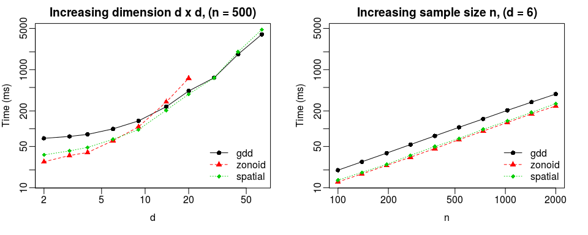

## Rank-based tests for HPD matrices with `pdRankTests()`

The null hypotheses of the available rank-based hypothesis tests in `pdRankTests()` are:

- `"rank.sum"`: homogeneity of distributions of two independent samples of HPD matrices (resp. sequences of HPD matrices).
- `"krusk.wall"`: homogeneity of distributions of more than two independent samples of HPD matrices (resp. sequences of HPD matrices).
- `"signed-rank"`: homogeneity of distributions of independent paired or matched samples of HPD matrices.
- `"bartels"`: exchangeability (i.e. randomness) within a single independent sample of HPD matrices (resp. sequences of HPD matrices).

Below, we construct several simulated examples for which (i) the null hypotheses listed above are satisfied, and (ii) the null hypotheses listed above are not satisfied. Analogous to the previous section, we generate pointwise random samples (resp. random samples of sequences) of `(2,2)`-dimensional HPD matrix-valued observations, with underlying geometric mean equal to the identity matrix (resp. sequence of scaled identity matrices).

Let’s first consider simulated examples of the manifold Wilcoxon rank-sum test (`"rank.sum"`) and manifold Kruskal-Wallis test (`"krusk.wall"`).

```r
## Generate data (null true)
data1 <- array(c(X1, replicate(50, Expm(diag(2), pdSpecEst:::E_coeff_inv(0.5 * rnorm(4))))), dim = c(2, 2, 100)) ## pointwise sample
data2 <- array(c(X2, replicate(50, sapply(1:5, function(i) Expm(i * diag(2), pdSpecEst:::T_coeff_inv(0.5 * rnorm(4), i * diag(2))), simplify = "array"))), dim = c(2, 2, 5, 100)) ## curve sample

## Generate data (null false)
data1a <- array(c(X1, replicate(50, Expm(diag(2), pdSpecEst:::E_coeff_inv(rnorm(4))))), dim = c(2, 2, 100)) ## pointwise scale change
data2a <- array(c(X2, replicate(50, sapply(1:5, function(i) Expm(i * diag(2), pdSpecEst:::T_coeff_inv(rnorm(4), i * diag(2))), simplify = "arra"))), dim = c(2, 2, 5, 100)) ## curve scale change

## Rank-sum test
pdRankTests(data1, sample.sizes = c(50, 50), "rank.sum")[1:4] ## null true (pointwise)
```

```
#> $test
#> [1] "Manifold Wilcoxon rank-sum"
#>
#> $p.value
#> [1] 0.1037495
#>
#> $statistic
#> [1] 1.626941
#>
#> $null.distr
#> [1] "Standard normal distribution"
```

```r
pdRankTests(data2, sample.sizes = c(50, 50), "rank.sum")[2] ## null true (curve)
```

```
#> $p.value
#> [1] 0.9834998
```

```r
pdRankTests(data1a, sample.sizes = c(50, 50), "rank.sum")[2] ## null false (pointwise)
```

```
#> $p.value
#> [1] 6.958285e-11
```

```r
pdRankTests(data2a, sample.sizes = c(50, 50), "rank.sum")[2] ## null false (curve)
```

```
#> $p.value
#> [1] 1.020181e-15
```

```r
## Kruskal-Wallis test
pdRankTests(data1, sample.sizes = c(50, 25, 25), "krusk.wall")[1:4] ## null true (pointwise)
```

```
#> $test
#> [1] "Manifold Kruskal-Wallis"
#>
#> $p.value
#> [1] 0.1443239
#>
#> $statistic
#> [1] 3.87139
#>
#> $null.distr
#> [1] "Chi-squared distribution (df = 2)"
```

```r
pdRankTests(data2, sample.sizes = c(50, 25, 25), "krusk.wall")[2] ## null true (curve)
```

```
#> $p.value
#> [1] 0.1526552
```

```r
pdRankTests(data1a, sample.sizes = c(50, 25, 25), "krusk.wall")[2] ## null false (pointwise)
```

```
#> $p.value
#> [1] 5.495634e-10
```

```r
pdRankTests(data2a, sample.sizes = c(50, 25, 25), "krusk.wall")[2] ## null false (curve)
```

```
#> $p.value
#> [1] 1.033775e-14
```

To apply the manifold Wilcoxon signed-rank test (`"signed-rank"`), we generate paired observations for independent trials (or subjects) by introducing trial-specific random effects, such that the paired observations in each trial share a trial-specific geometric mean. Note that for such data the manifold Wilcoxon rank-sum test is no longer valid due to the introduced sample dependence.

```r
## Trial-specific means
mu <- replicate(50, Expm(diag(2), pdSpecEst:::E_coeff_inv(0.1 * rnorm(4))))

## Generate paired samples X,Y
make_sample <- function(null) sapply(1:50, function(i) Expm(mu[, , i], pdSpecEst:::T_coeff_inv(ifelse(null, 1, 0.5) * rexp(4) - 1, mu[, , i])), simplify = "array")

X3 <- make_sample(null = T)
Y3 <- make_sample(null = T) ## null true
Y3a <- make_sample(null = F) ## null false (scale change)

## Signed-rank test
pdRankTests(array(c(X3, Y3), dim = c(2, 2, 100)), test = "signed.rank")[1:4] ## null true
```

```
#> $test
#> [1] "Manifold Wilcoxon signed-rank"
#>
#> $p.value
#> [1] 0.2025809
#>
#> $statistic
#>   V
#> 505
#>
#> $null.distr
#> [1] "Wilcoxon signed rank test with continuity correction"
```

```r
pdRankTests(array(c(X3, Y3a), dim = c(2, 2, 100)), test = "signed.rank")[2] ## null false
```

```
#> $p.value
#> [1] 0.001444632
```

The manifold signed-rank test also provides a valid procedure to test for equivalence of spectral matrices of two (independent) multivariate stationary time series based on the HPD periodogram matrices obtained via `pdPgram()`. In contrast to other available tests in the literature, this asymptotic test does not require consistent spectral estimators or resampling/bootstrapping of test statistics, and therefore remains computationally efficient for higher-dimensional spectral matrices or a large number of sampled Fourier frequencies.

```r
## Signed-rank test for equivalence of spectra
## ARMA(1,1) process: Example 11.4.1 in (Brockwell and Davis, 1991)
Phi <- array(c(0.7, 0, 0, 0.6, rep(0, 4)), dim = c(2, 2, 2))
Theta <- array(c(0.5, -0.7, 0.6, 0.8, rep(0, 4)), dim = c(2, 2, 2))
Sigma <- matrix(c(1, 0.71, 0.71, 2), nrow = 2)
pgram <- function(Sigma) pdPgram(rARMA(2^9, 2, Phi, Theta, Sigma)$X)$P ## HPD periodogram

## Null is true
pdRankTests(array(c(pgram(Sigma), pgram(Sigma)), dim = c(2, 2, 2^8)), test = "signed.rank")[2]
```

```
#> $p.value
#> [1] 0.4045394
```

```r
## Null is false
pdRankTests(array(c(pgram(Sigma), pgram(0.5 * Sigma)), dim = c(2, 2, 2^8)), test = "signed.rank")[2]
```

```
#> $p.value
#> [1] 5.058065e-14
```

To apply the manifold Bartels-von Neumman test (`"bartels"`), we generate an independent non-identically distributed sample with a trend in the scale of the distribution across observations, such that the null hypothesis of randomness breaks down.

```r
## Null is true
data3 <- replicate(200, Expm(diag(2), pdSpecEst:::E_coeff_inv(rnorm(4)))) ## pointwise samples
data4 <- replicate(100, sapply(1:5, function(i) Expm(i * diag(2), pdSpecEst:::T_coeff_inv(rnorm(4), i * diag(2))), simplify = "array")) ## curve samples

## Null is false
data3a <- sapply(1:200, function(j) Expm(diag(2), pdSpecEst:::E_coeff_inv(((200 - j) / 200 + j * 2 / 200) * rnorm(4))), simplify = "array") ## pointwise trend in scale
data4a <- sapply(1:100, function(j) sapply(1:5, function(i) Expm(i * diag(2), pdSpecEst:::T_coeff_inv(((100 - j) / 100 + j * 2 / 100) * rnorm(4), i * diag(2))), simplify = "array"), simplify = "array") ## curve trend in scale

## Bartels-von Neumann test
pdRankTests(data3, test = "bartels")[1:4] ## null true (pointwise)
```

```
#> $test
#> [1] "Manifold Bartels-von Neumann"
#>
#> $p.value
#> [1] 0.8931316
#>
#> $statistic
#> [1] 0.1343427
#>
#> $null.distr
#> [1] "Standard normal distribution"
```

```r
pdRankTests(data4, test = "bartels")[2] ## null true (curve)
```

```
#> $p.value
#> [1] 0.260438
```

```r
pdRankTests(data3a, test = "bartels")[2] ## null false (pointwise)
```

```
#> $p.value
#> [1] 0.0005847046
```

```r
pdRankTests(data4a, test = "bartels")[2] ## null false (curve)
```

```
#> $p.value
#> [1] 0.0001358793
```

### Computation times

The figures below display average computation times in milliseconds (single core, Intel Xeon E5-2650) of the rank-based hypothesis tests in terms of the dimension of the matrix-valued data and the size of the samples considered in the tests.

**Manifold Wilcoxon rank-sum test** The figure below displays average computation times of the manifold Wilcoxon rank-sum test for two equal-sized samples of `(d,d)`-dimensional HPD matrices of size `n`, with depth-induced ranks based on the geodesic distance depth (`gdd`), manifold zonoid depth (`zonoid`) and manifold spatial depth (`spatial`) respectively.

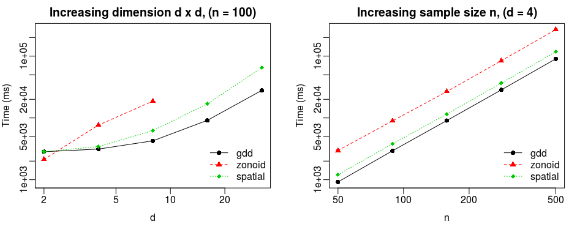

**Manifold Kruskal-Wallis test** The figure below displays average computation times of the manifold Kruskal-Wallis test for three equal-sized samples of `(d,d)`-dimensional HPD matrices of size `n`, with depth-induced ranks based on the geodesic distance depth (`gdd`), manifold zonoid depth (`zonoid`) and manifold spatial depth (`spatial`) respectively.

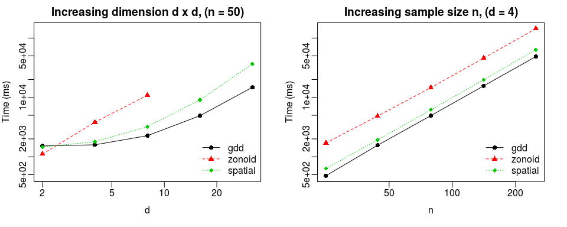

**Manifold Bartels-von Neumann test** The figure below displays average computation times of the manifold Bartels-von Neumann test for a single sample of size `n` of `(d,d)`-dimensional HPD matrices, with depth-induced ranks based on the geodesic distance depth (`gdd`), manifold zonoid depth (`zonoid`) and manifold spatial depth (`spatial`) respectively.

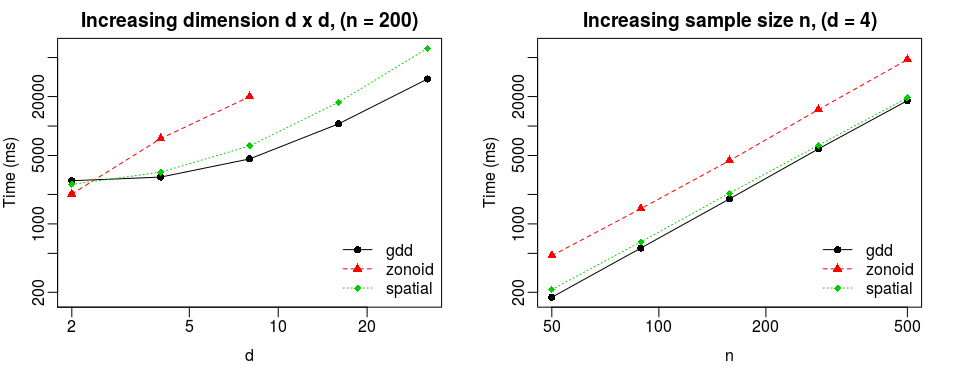

**Manifold Wilcoxon signed-rank test** The figure below displays average computation times of the manifold Wilcoxon signed-rank test for two equal-sized samples of size `n` of `(d,d)`-dimensional HPD matrices. This test is not based on data depth but on a specific manifold difference score.

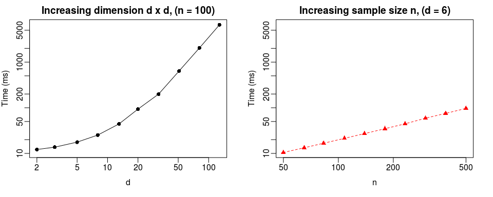

## References

Chau, J., H. Ombao, and R. von Sachs. 2017. “Data Depth and Rank-Based Tests for Covariance and Spectral Density Matrices.” http://arxiv.org/abs/1706.08289.